# Assignment four

Christianna Parr

May 30, 2017

```r
library (tidyverse)
library (rio)
library (broom)
library (plm)
library (car)
library (AER)
```

```r
library (ggplot2)
library(modelr)
library(rdrobust)
```

### Question 8.2

```r
peace <- import ("PeaceCorpsHW.dta")
```

### a) Relationship between peace corps applications and unemployment?

I would assume there would be a positive corelation between the two variables. This could be because when unemployment is high people will apply for alternative experiences like the Peace Corps, due to a lack of other options being available. Therefore, the effect of unemployment on peace corps applications might be positively corelated.

### b) Pooled regression

```r
pool1 <- lm (appspc ~ unemployrate + yr1 + yr2 + yr3 + yr4 + yr5 + yr6, data = peace)

tidy(pool1)
```

```
##           term  estimate std.error statistic    p.value
## 1  (Intercept) 37.126654 14.748783 2.5172689 0.01234961
## 2 unemployrate  1.106939  1.631738 0.6783805 0.49805516
## 3          yr1 10.388230 10.863460 0.9562542 0.33971631
## 4          yr2  5.049742 10.932244 0.4619127 0.64447983
## 5          yr3 10.053185 10.123210 0.9930827 0.32147261
## 6          yr4 13.001321  8.999862 1.4446134 0.14961362
## 7          yr5  5.384465  9.041287 0.5955419 0.55193183
```

Ceteris paribus, there does not appear to be a significant relationship at the alpha equals 0.05 level. We cannot reject the null hypothesis that these variables may not be related.

### c) Plot to look for outliers

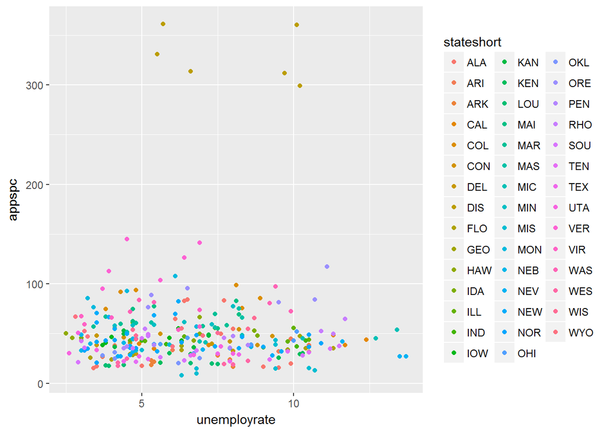

```r
ggplot (data = peace) +
  geom_point (mapping = aes(y = appspc, x = unemployrate, color = stateshort))
```

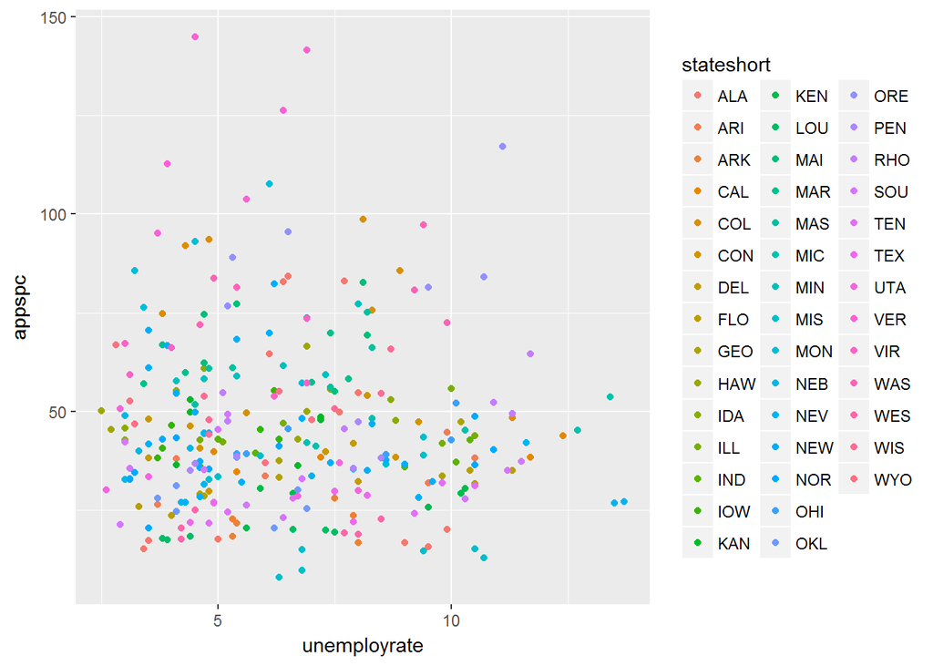

```r
peace1 <- peace %>%
  filter (appspc < 250)

ggplot (data = peace1) +
  geom_point (mapping = aes (x = unemployrate, y = appspc, color = stateshort))
```

Once application numbers over the level of 250 are removed (District of Columbia) we can see that there is not really a relationship between the two observations. The data is easier to see because it is not being distorted by the significant outlier.

### d) Pooled model with new data

```r
pool2 <- lm (appspc ~ unemployrate + yr1 + yr2 + yr3 + yr4 + yr5 + yr6, data = peace1)

tidy(pool2)
```

```
##           term  estimate std.error  statistic      p.value
## 1  (Intercept) 57.027940 7.0781016  8.0569542 1.994724e-14
## 2 unemployrate -1.963543 0.7860275 -2.4980588 1.303566e-02
## 3          yr1 -2.183451 5.2328858 -0.4172557 6.767970e-01
## 4          yr2 -7.244454 5.2647692 -1.3760251 1.698647e-01
## 5          yr3  1.164934 4.8780991  0.2388090 8.114207e-01
## 6          yr4 13.989168 4.3439206  3.2204014 1.424092e-03
## 7          yr5  6.191496 4.3643673  1.4186468 1.570648e-01
```

### e) LSDV approach, 2 way fixed effects

```r
lsdv <- lm (appspc ~ unemployrate + yr1 + yr2 + yr3 + yr4 +yr5 + yr6 + factor (state), data = peace1)
tidy(lsdv)
```

```
##                           term    estimate std.error  statistic
## 1                  (Intercept)   5.2156276 4.6527237  1.1209838
## 2                 unemployrate   0.8124859 0.4673662  1.7384351
## 3                          yr1   8.1600318 2.1173862  3.8538230
## 4                          yr2   3.2989029 2.1451468  1.5378448
## 5                          yr3   9.0544074 1.7930667  5.0496767
## 6                          yr4  13.0952868 1.2138679 10.7880662
## 7                          yr5   4.4537018 1.2395262  3.5930678
## 8          factor(state)ALASKA  52.5355143 3.4805888 15.0938585
## 9         factor(state)ARIZONA  17.9572417 3.4871720  5.1495142
## 10       factor(state)ARKANSAS   4.9350529 3.4778072  1.4190128
## 11     factor(state)CALIFORNIA  21.8179665 3.6129641  6.0387997
## 12       factor(state)COLORADO  69.9746437 3.4809461 20.1021911
## 13    factor(state)CONNECTICUT  28.9192713 3.4774146  8.3163139
## 14       factor(state)DELAWARE  21.9694339 3.5015232  6.2742505
```

[output cut: 99 more lines]

We still do not find significance at the alpha equals 0.05 level, and cannot reject the null hypothesis. There does not appear to be a significant relationship between unemployment and peace corps applications. These results are preferable since they take state level fixed effects into account.

### f) 2 way fixed effects

```r
fixed <- plm (appspc ~ unemployrate, data = peace1, index = c("state", "year"), model = "within", effect = "twoways")

tidy (fixed)
```

```
##           term  estimate std.error statistic   p.value
## 1 unemployrate 0.8124859 0.4673662  1.738435 0.0833956
```

When we run a two way fixed effects model we find the same result, because these are the same method (two way LDSV and two way fixed effects). They are both effective in discovering the same result.

### Exercise 8.5

```r
texas <- import ("TexasSchoolBoard.dta")
```

### a) Pooled model

```r
pool3 <- lm (LnAvgSalary ~ OnCycle, data = texas)
tidy (pool3)
```

```
##          term    estimate   std.error    statistic      p.value
## 1 (Intercept) 10.67136324 0.001018375 10478.814561 0.000000e+00
## 2     OnCycle -0.03062071 0.003766094    -8.130628 4.995323e-16
```

The p value is highly significant! There is bias in the data because a powerful teacher’s union could shape when an election could occur and negotiate for better salaries. Therefore, these results are best viewed with skepticism.

### b) Diff in Diff Model

```r
diff <- lm (LnAvgSalary ~ CycleSwitch + AfterSwitch + AfterCycleSwitch, data = texas)
tidy(diff)
```

```
##               term     estimate   std.error   statistic      p.value
## 1      (Intercept) 10.671067840 0.001432820 7447.597740 0.000000e+00
## 2      CycleSwitch -0.023982423 0.003397199   -7.059469 1.827501e-12
## 3      AfterSwitch  0.009303057 0.002188484    4.250914 2.155893e-05
## 4 AfterCycleSwitch -0.008590132 0.005189230   -1.655377 9.789166e-02
```

When looking at the diff in diff, we know that AfterCycleSwitch is the variable of interest. For this variable we do not find statistical significance at the alpha equals 0.05 level, and thus cannot reject the null hypothesis. We find that election time does not have a statistically significant relationship with teacher’s salaries.

CycleSwitch: The districts which switched experience a decline in salary of 2.3%.

AfterSwitch tells us the change in salary for all districts and it shows a statistically significant positive change in salaries after the switch (under 1%).

### c) One way fixed effect model

```r
oneway <- plm (LnAvgSalary ~ OnCycle, index = c("DistNumber"), model = "within", data = texas)
tidy (oneway)
```

```
##      term     estimate   std.error statistic   p.value
## 1 OnCycle 0.0007903361 0.002077312 0.3804609 0.7036165
```

From this one way fixed effect model there is no statistically significant effect on teacher salary, and we cannot reject the null hypothesis.

The model doesn’t account for trends which can effect districts, only the district ID number.

### d) Two way fixed effect model

```r
twoway <- plm (LnAvgSalary ~ OnCycle, index = c("DistNumber", "Year"), model = "within", effect = "twoways", data = texas)

tidy (twoway)
```

```
##      term     estimate   std.error statistic      p.value
## 1 OnCycle -0.008516084 0.002024592  -4.20632 2.632738e-05
```

In this model we see that OnCycle now has a statistically significant effect on the average salary. The model accounts for preexisting conditions of the switching districts because it compares the data within districts and not just grouping everything together. It also accounts for the post-switch years for all the districts because the fixed effect for all years is included.

### e) Subsetted data

We cannot estimate the effect of OnCycle for average salary since the switch occurs in 2007. We cannot compare district before and after the switch to themselves. We do not use anything before 2007 so we cannot see how things were before the switch.

### Question 11.3

```r
congress <- import ("CongressRD.dta") %>%
  mutate(GOPwin2010 = factor(GOPwin2010))
```

### a) Endogeneity

There could be a problem with endogeneity since the district of the congress member might effect their ideology and the political party they are in. Various other factors on ideology and political party include the percentage of whites in the district, child poverty, median income, and level of support for the national party.

### b)

Using an RD model we can fight endogeneity because we can use the difference around an election of a Republican or Democrat to Congress, as districts with close elections should be similar to each other. We are also selecting quasi-randomly. Therefore we control for some district level effects.

### c) Scatterplot

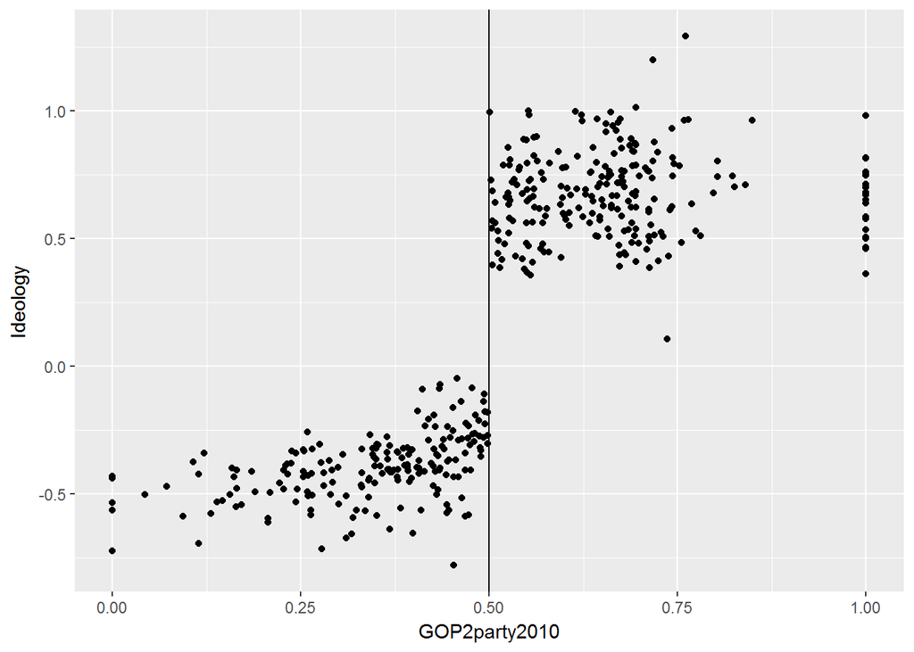

```r
ggplot (data = congress) +
  geom_point (mapping = aes (x = GOP2party2010, y = Ideology)) +
  geom_vline(xintercept = 0.50)
```

The RD will probably indicate that there is an ideological divide between the Democrats and Republicans.

### d) Equation

$$Ideology_i = \beta_0 + \beta_1*GOPwin2010_i + \beta_2*(GOP2party2010_{1i} - 0.50) + \epsilon_i$$

Ideology is the variable of interest which we are explaining. $\beta_0$ is the intercept. It is where the democratic ideology jumps suddenly to the republican ideology. The cut off point. $\beta_1$ is added to $\beta_0$ to find the cut off point. $\beta_2$ is the slope which is equal for both the parties in this basic RD model. $\epsilon_i$ is the error term, which we assume is constant for both groups.

### e) RD Model

```r
rd <- lm (Ideology ~ GOPwin2010 + I(GOP2party2010 - 0.50), data = congress)
tidy(rd)
```

```
##                     term   estimate  std.error  statistic       p.value
## 1            (Intercept) -0.3598854 0.01409579 -25.531417  4.108969e-88
## 2            GOPwin20101  0.9951733 0.02381502  41.787627 2.518714e-153
## 3 I(GOP2party2010 - 0.5)  0.2304440 0.05710825   4.035214  6.459328e-05
```

The democrats at the intercept have an average ranking at - 0.35 but republicans at the intercept have a ranking of 0.65 (which we can get from intercept - GOPwin2010). Every percentage change in the vote share changes ideology by 0.23.

### f)

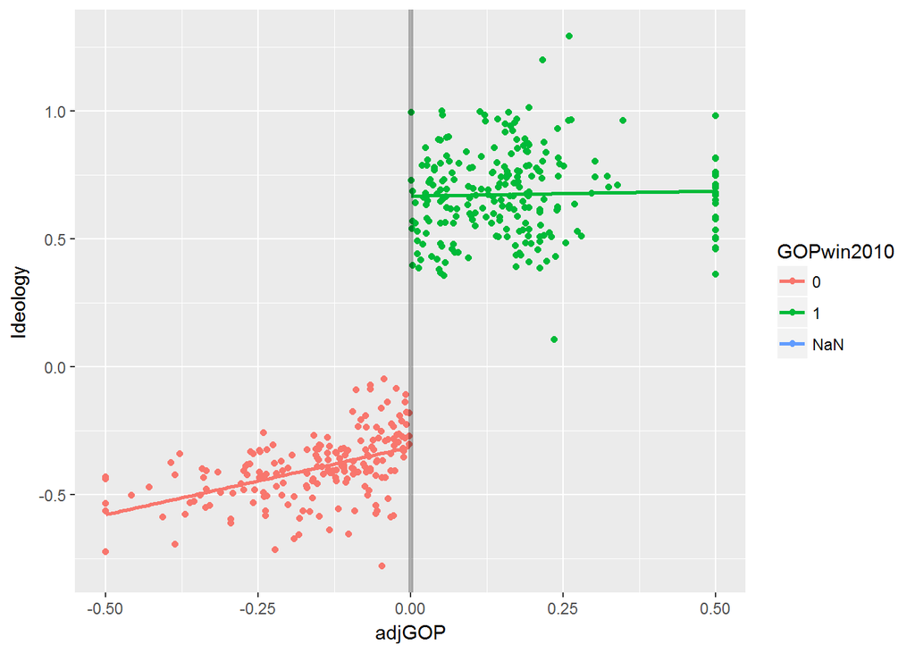

```r
congress <- congress %>%
  mutate (adjGOP = GOP2party2010 - 0.5) %>%
  mutate (GOPint = as.numeric(GOPwin2010) * adjGOP)

congVAR <- lm (Ideology ~ GOPwin2010 * adjGOP, data = congress)

tcongVAR <- tidy (congVAR)

#plotting

ggplot (data = congress) +
  geom_point (aes (y = Ideology, x = adjGOP, color = GOPwin2010), na.rm = FALSE) +
  geom_smooth (aes (y = Ideology, x = adjGOP, color = GOPwin2010), method = "lm", se = FALSE) +
  geom_vline (aes(xintercept = 0), color = "black", size = 1.3, alpha = 0.3)
```

```r
# fitted values

predfit <- data.frame(GOPwin2010 = as.factor(c(0,0,1,1)), adjGOP = c(-0.5, 0, 0, 0.5))

predict (congVAR, newdata = predfit)
```

```
##          1          2          3          4
## -0.5775762 -0.3132725  0.6682932  0.6879330
```

### g) Unadjusted Model

```r
uncongVAR <- lm (Ideology ~ GOPwin2010 * GOP2party2010, data = congress)

tidy (uncongVAR)
```

```
##                        term   estimate  std.error  statistic      p.value
## 1               (Intercept) -0.5775762 0.03259478 -17.719901 4.310325e-53
## 2               GOPwin20101  1.2262296 0.05901227  20.779230 8.035207e-67
## 3             GOP2party2010  0.5286074 0.08959227   5.900145 7.389326e-09
## 4 GOPwin20101:GOP2party2010 -0.4893277 0.11477395  -4.263404 2.479081e-05
```

```r
unpredfit <- data.frame(GOPwin2010 = as.factor(c(0,0,1,1)), GOP2party2010 = c(0, 0.5, 0.5, 1))

predict (uncongVAR, newdata = unpredfit)
```

```
##          1          2          3          4
## -0.5775762 -0.3132725  0.6682932  0.6879330
```

### h) Clustering of the dependent variable

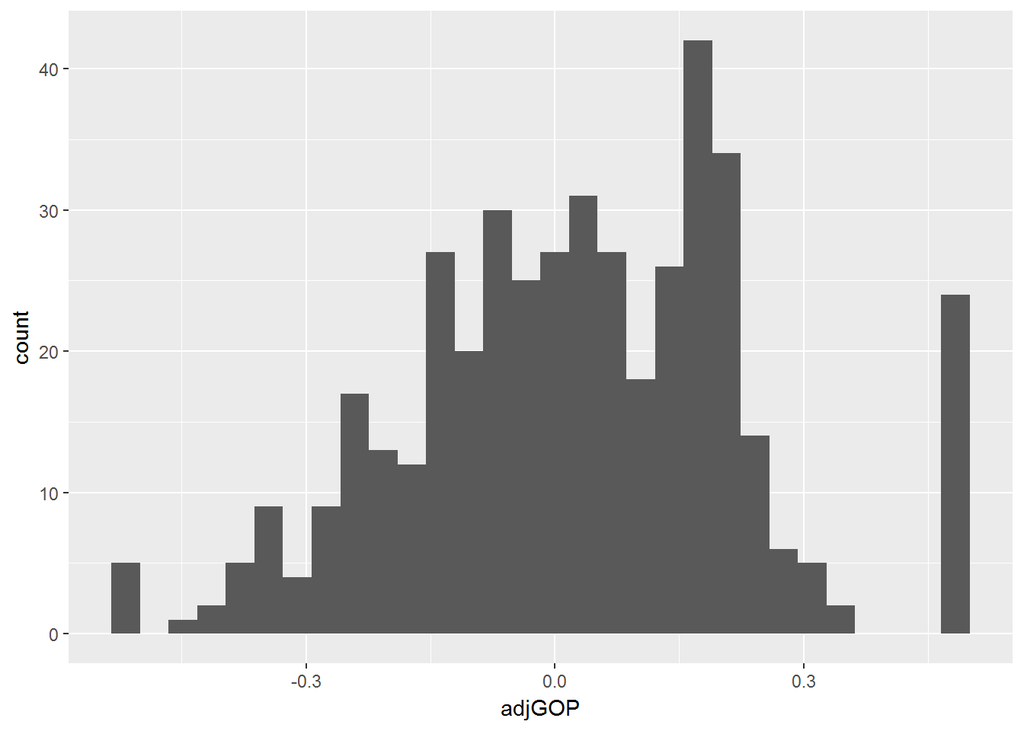

```r
ggplot (data = congress) +
  geom_histogram(aes(x = adjGOP))
```

From this histogram there does not appear to be any clustering of the data.

### i) Discontinuities for the other variables.

```r
child <- lm (ChildPoverty ~ GOPwin2010 + adjGOP, data = congress)
tidy(child)
```

```
##          term    estimate   std.error  statistic      p.value
## 1 (Intercept)  0.20785971 0.007464587 27.8461107 1.835408e-98
## 2 GOPwin20101 -0.01216113 0.012624222 -0.9633173 3.359272e-01
## 3      adjGOP -0.09769107 0.030315571 -3.2224717 1.367117e-03
```

```r
income <- lm (MedianIncome ~ GOPwin2010 + adjGOP, data = congress)
tidy (income)
```

```
##          term   estimate std.error  statistic       p.value
## 1 (Intercept) 52318.7456  1273.481 41.0832549 2.608996e-151
## 2 GOPwin20101  -388.1231  2153.730 -0.1802097  8.570724e-01
## 3      adjGOP  2920.0938  5171.928  0.5646045  5.726358e-01
```

```r
obama <- lm (Obama2008 ~ GOPwin2010 + adjGOP, data = congress)
tidy(obama)
```

```
##          term    estimate   std.error  statistic       p.value
## 1 (Intercept)  0.57667389 0.006244357  92.351208 1.421607e-286
## 2 GOPwin20101 -0.04339804 0.010560551  -4.109448  4.746549e-05
## 3      adjGOP -0.55242270 0.025359910 -21.783307  1.568037e-71
```

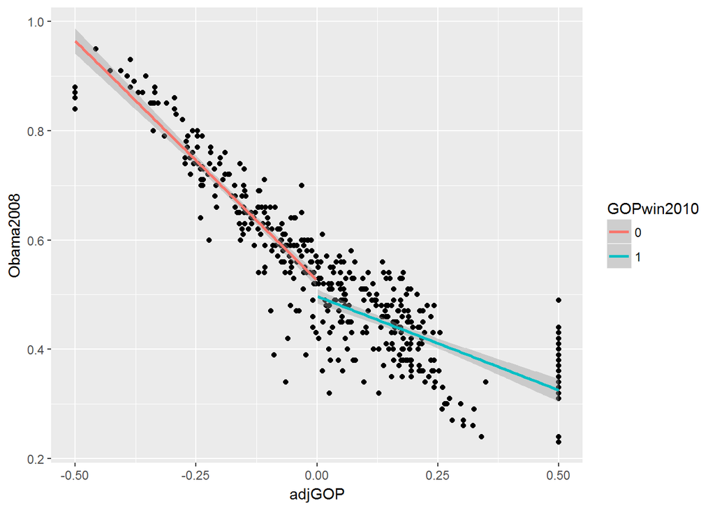

```r
# this result may be biased and it shows discontinuity. I plot it and then remove some outliers who are changing the result.

ggplot (data = congress) +
  geom_point (aes (x = adjGOP, y = Obama2008)) +
  geom_smooth (aes (x = adjGOP, y = Obama2008, color = GOPwin2010), method = "lm")
```

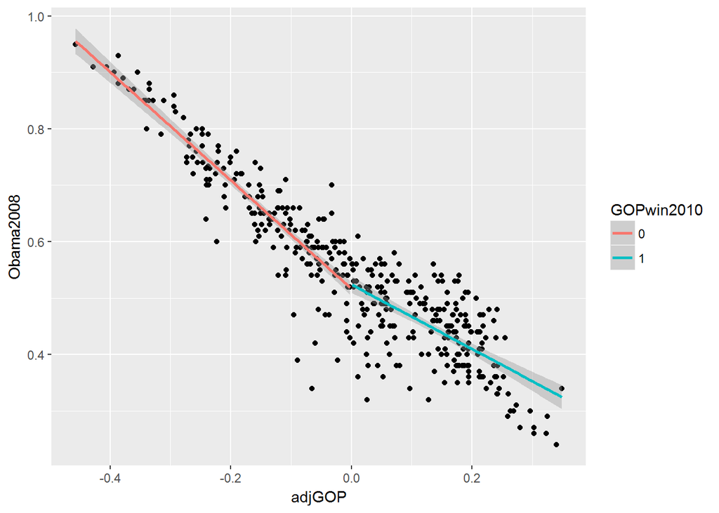

```r
# there appears to be a discontinuity but there are some results at the 0.5 level causing bias. I remove these

ggplot (data = filter(congress, abs(adjGOP) != 0.5)) +
          geom_point (aes (x = adjGOP, y = Obama2008)) +
          geom_smooth (aes (x = adjGOP, y = Obama2008, color = GOPwin2010), method = "lm")
```

```r
# once they are removed the discontinuity is gone.

white <- lm (WhitePct ~ GOPwin2010 + adjGOP, data = congress)

tidy(white)
```

```
##          term   estimate  std.error statistic       p.value
## 1 (Intercept) 0.64542569 0.01762471 36.620508 1.528993e-134
## 2 GOPwin20101 0.05952964 0.02980717  1.997158  4.643479e-02
## 3      adjGOP 0.49384356 0.07157838  6.899339  1.867851e-11
```

### j)

```r
conVAR <- lm (Ideology ~ GOPwin2010 * adjGOP + ChildPoverty + MedianIncome +
                   Obama2008 + WhitePct, data = congress)

tidy (conVAR)
```

```
##                 term      estimate    std.error  statistic       p.value
## 1        (Intercept) -1.340566e-02 1.272320e-01 -0.1053639  9.161369e-01
## 2        GOPwin20101  9.627815e-01 2.286945e-02 42.0990312 1.570623e-153
## 3             adjGOP -4.762371e-02 1.416603e-01 -0.3361824  7.368996e-01
## 4       ChildPoverty  2.651014e-01 1.885303e-01  1.4061474  1.604128e-01
## 5       MedianIncome  2.120959e-06 1.008738e-06  2.1025871  3.609088e-02
## 6          Obama2008 -7.905298e-01 1.242559e-01 -6.3621102  5.164714e-10
## 7           WhitePct -6.085770e-02 4.978006e-02 -1.2225318  2.221857e-01
## 8 GOPwin20101:adjGOP -1.770715e-01 1.365759e-01 -1.2965064  1.955062e-01
```

### k) Quadratic Model

```r
# squaring the running variable

quadratic <- lm (Ideology ~ GOPwin2010 * I(adjGOP ^ 2) + GOPwin2010 * adjGOP + ChildPoverty +
                   MedianIncome + WhitePct + Obama2008, data = congress)

tidy (quadratic)
```

```
##                       term      estimate    std.error   statistic
## 1              (Intercept) -3.166341e-03 1.275785e-01 -0.02481877
## 2              GOPwin20101  9.088784e-01 3.255069e-02 27.92193698
## 3              I(adjGOP^2)  1.022459e+00 6.002693e-01  1.70333346
## 4                   adjGOP  4.515318e-01 3.048272e-01  1.48127126
## 5             ChildPoverty  2.659147e-01 1.878215e-01  1.41578397
## 6             MedianIncome  2.112532e-06 1.007358e-06  2.09710234
## 7                 WhitePct -7.393342e-02 4.991831e-02 -1.48108824
## 8                Obama2008 -7.364179e-01 1.265387e-01 -5.81970611
## 9  GOPwin20101:I(adjGOP^2) -1.709260e+00 7.442130e-01 -2.29673422
## 10      GOPwin20101:adjGOP -3.097497e-01 3.537159e-01 -0.87570209
##         p.value
## 1  9.802112e-01
## 2  6.185328e-98
## 3  8.924193e-02
## 4  1.392806e-01
## 5  1.575764e-01
## 6  3.657905e-02
## 7  1.393293e-01
## 8  1.167569e-08
## 9  2.212294e-02
## 10 3.816902e-01
```

### l)

```r
filtcon <- congress %>%
  filter (adjGOP > -0.1) %>%
  filter (adjGOP < 0.1)

filt <- lm (Ideology ~ GOPwin2010 * adjGOP + ChildPoverty + MedianIncome +
              Obama2008 + WhitePct, data = filtcon)
tidy (filt)
```

```
##                 term      estimate    std.error  statistic      p.value
## 1        (Intercept)  1.014672e-01 2.410422e-01  0.4209518 6.744136e-01
## 2        GOPwin20101  8.641359e-01 4.713429e-02 18.3334885 1.358749e-39
## 3             adjGOP  8.688370e-01 6.231758e-01  1.3942085 1.653873e-01
## 4       ChildPoverty  2.694340e-01 3.555991e-01  0.7576905 4.498659e-01
## 5       MedianIncome  9.332218e-07 1.745713e-06  0.5345793 5.937596e-01
## 6          Obama2008 -7.899501e-01 2.064849e-01 -3.8257040 1.932137e-04
## 7           WhitePct -5.493087e-02 8.914930e-02 -0.6161671 5.387503e-01
## 8 GOPwin20101:adjGOP -6.744964e-01 8.637691e-01 -0.7808758 4.361485e-01
```

### Question 11.4

```r
headstart <- import ("LudwigMiller_head_start.dta") %>%
  filter (!is.na(Poverty)) %>%
  filter (!is.na(Mortality))
```

### a) Equation

In this model I forsee mortality to increase with poverty, with a discontinuity at the 0 point. However, when Head Start is implemented there will then be a decrease in mortality. Then after this decrease there will be an increase again, since poverty is still increasing on the scale. So an image of a line going up and then hitting a specific point, then decreasing, then going up again.

### b)

RD is able to estimate a causal effect because there is a specific cut off point where the program is implemented. The counties are less likely to be able to manipulate their poverty rate and select into the program. Therefore, there is a randomness to the treatment being recieved.

### c) Basic RD

```r
headrd <- lm (Mortality ~ HeadStart + Poverty, data = headstart)
tidy(headrd)
```

```
##          term   estimate  std.error statistic      p.value
## 1 (Intercept)  3.1094673 0.24384851 12.751635 2.456672e-36
## 2   HeadStart -0.9130971 0.43365749 -2.105572 3.532175e-02
## 3     Poverty  0.3376749 0.07790943  4.334198 1.509438e-05
```

In this basic RD model we can see that there is a statistically significant result at the alpha equals 0.05 level. Head start appears to have an effect on mortality rate, in a negative way (which is a good thing). We can reject the null hypothesis.

### d) Varying Slopes Model

```r
headvar <- lm (Mortality ~ HeadStart * Poverty, data = headstart)
tidy(headvar)
```

```
##                term   estimate  std.error  statistic      p.value
## 1       (Intercept)  3.1009019 0.24552619 12.6296176 1.081019e-35
## 2         HeadStart -1.0267779 0.57416342 -1.7883025 7.382485e-02
## 3           Poverty  0.3346506 0.07856105  4.2597522 2.107414e-05
## 4 HeadStart:Poverty  0.1863191 0.61663021  0.3021569 7.625527e-01
```

In this model the head start program is no longer significant with regards to mortality rates. Therefore, we cannot reject the null hypothesis.

### e) Adjusted model

```r
headfilt <- headstart %>%
  filter (Poverty > -0.8) %>%
  filter (Poverty < 0.8)

rdfilt <- lm (Mortality ~ HeadStart + Poverty, data = headfilt)
tidy(rdfilt)
```

```
##          term  estimate std.error statistic      p.value
## 1 (Intercept)  3.785846 0.5605933  6.753284 4.198139e-11
## 2   HeadStart -2.103486 0.9960812 -2.111762 3.522409e-02
## 3     Poverty  1.840813 1.0944909  1.681890 9.324197e-02
```

### f) Quadratic Model

```r
headquad <- lm (Mortality ~ HeadStart * Poverty + HeadStart * I(Poverty ^ 2), data = headstart)
tidy (headquad)
```

```
##                     term    estimate  std.error  statistic      p.value
## 1            (Intercept)  3.31972730 0.38071063  8.7198177 4.463264e-18
## 2              HeadStart -1.85127701 0.83463729 -2.2180617 2.662289e-02
## 3                Poverty  0.56339635 0.31412815  1.7935239 7.298669e-02
## 4           I(Poverty^2)  0.04392462 0.05840314  0.7520935 4.520520e-01
## 5      HeadStart:Poverty  2.17291614 2.06138270  1.0541061 2.919165e-01
## 6 HeadStart:I(Poverty^2) -1.25453341 1.06356975 -1.1795497 2.382699e-01
```

### g) Scatterplot

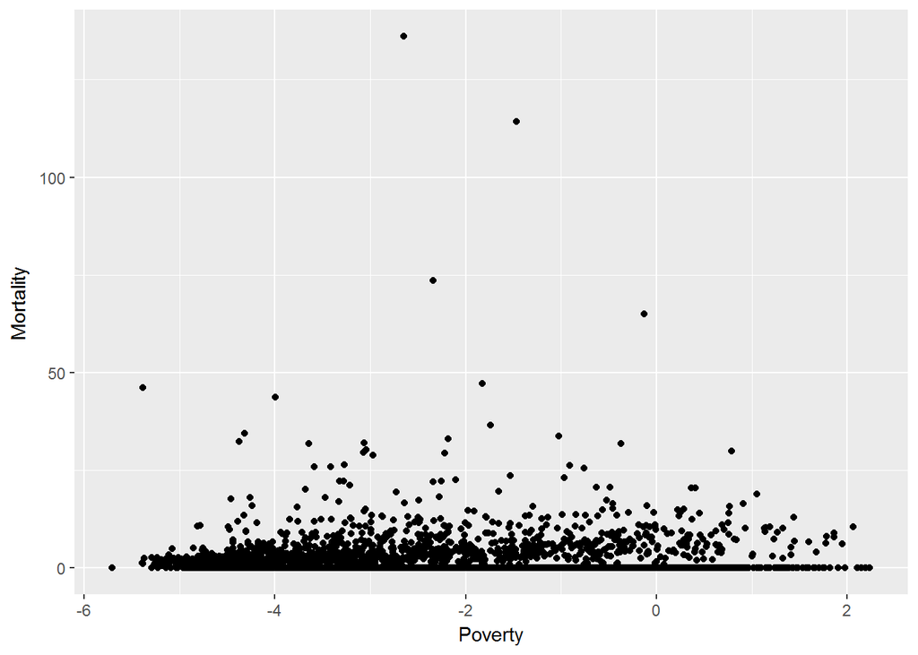

```r
ggplot (data = headstart) +
  geom_point (aes (x = Poverty, y = Mortality))
```

There appears to not be a relationship that could produce a discontinuity design with this data.

### h)

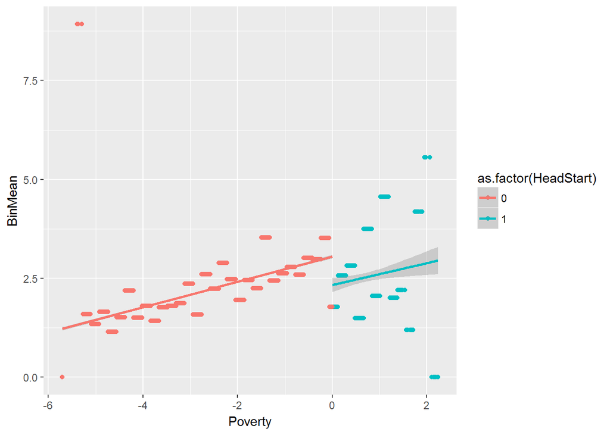

```r
ggplot (data = headstart) +
  geom_point (aes (y = BinMean, x = Poverty, color = as.factor(HeadStart))) +
  geom_smooth (aes (x = Poverty, y = BinMean, color = as.factor(HeadStart)), method = "lm")
```

The code was in Stata so translated into R. There appears to be a discontinuity now! When we use the binned mean values this appears.

### i)

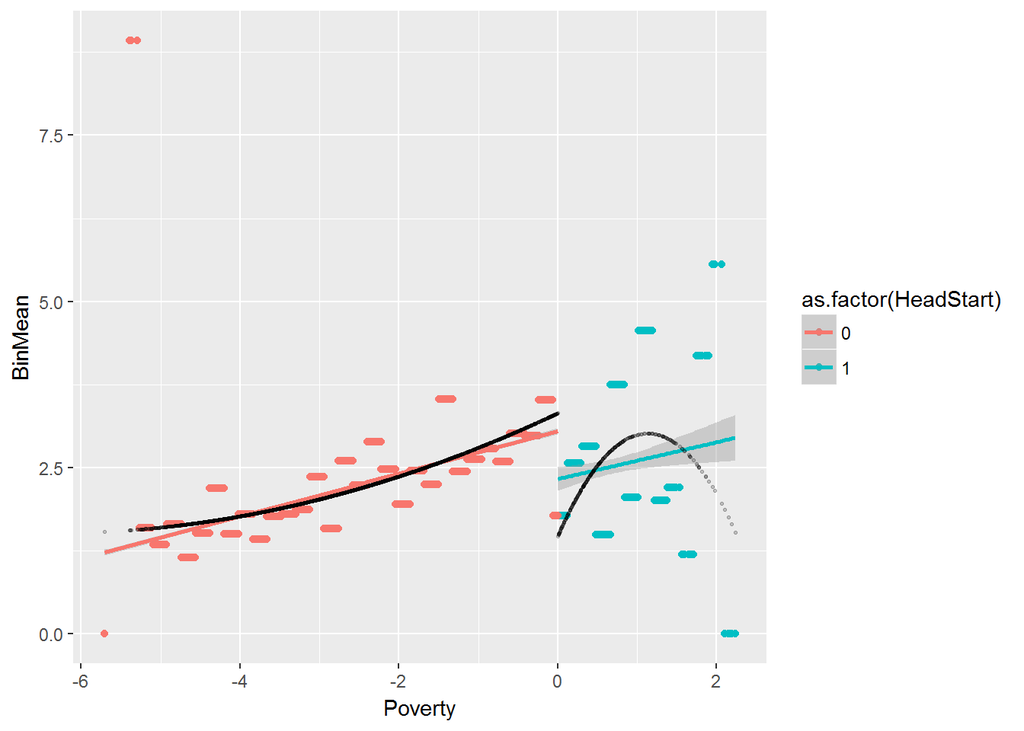

```r
headstart$fitted <- headquad$fitted.values

ggplot (data = headstart) +
  geom_point (aes (y = BinMean, x = Poverty, color = as.factor(HeadStart))) +
  geom_smooth (aes (x = Poverty, y = BinMean, color = as.factor(HeadStart)), method = "lm") +
  geom_point (aes (x = Poverty, y = fitted), alpha = 0.2, size = 0.5)
```

From this quadratic model with the fitted values, we can see that it works well for the control group. However, for the treatment group the relationship is problematic. The binned means shows that there is a significant variance in the treatment, therefore we cannot be certain about the causal effects of the Head Start program.

### Question 13.3

```r
bond <- import ("BondUpdate.dta")
```

### a) OLS model

```r
regbond <- lm (GrossRev ~ Rating + Budget, data = bond)
tidy(regbond)
```

```
##          term     estimate   std.error statistic    p.value
## 1 (Intercept) -590.8833844 365.9506205 -1.614653 0.12205252
## 2      Rating  172.6289093  52.7899822  3.270107 0.00383015
## 3      Budget    0.6222145   0.6009557  1.035375 0.31285138
```

We find statistically significant results at the alpha equals 0.05 level for the rating of the film and the gross revenue. A one unit increase in rating is associated with a gross revenue increase of 172 million pounds.

### Is there autocorrelation?

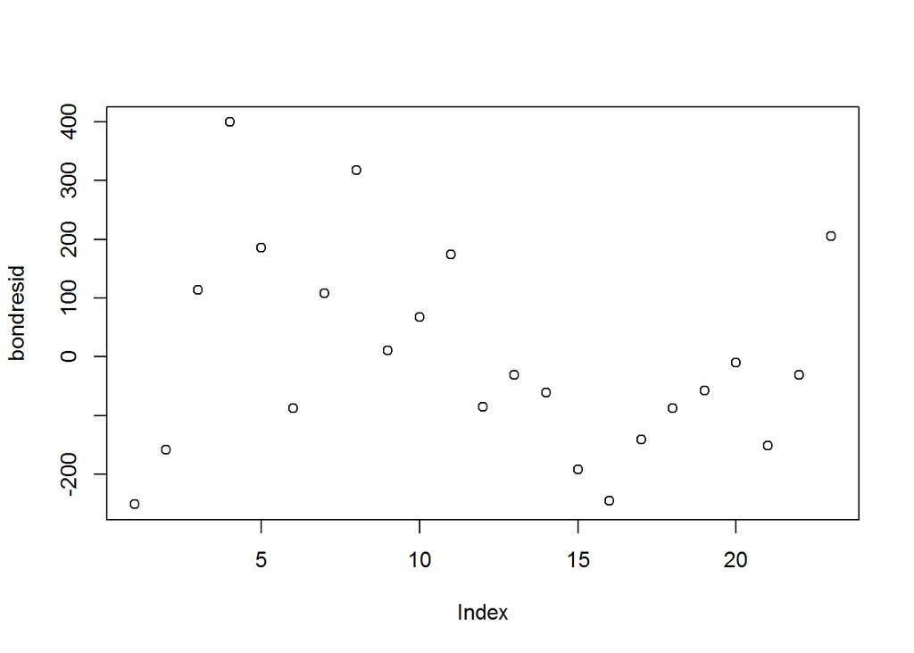

```r
bondresid <- resid(regbond)

plot (bondresid)
```

```r
lagbond <- c(NA, bondresid[1:(length(bondresid) - 1)])

legbondreg <- lm (bondresid ~ lagbond)

summary (legbondreg)
```

```
##
## Call:
## lm(formula = bondresid ~ lagbond)
##
## Residuals:
##     Min      1Q  Median      3Q     Max
## -184.49 -123.64  -21.64  108.74  333.53
##
## Coefficients:
##             Estimate Std. Error t value Pr(>|t|)
## (Intercept)  15.4928    32.7731   0.473   0.6415
## lagbond       0.4398     0.1963   2.240   0.0366 *
## ---
## Signif. codes:  0 '***' 0.001 '**' 0.01 '*' 0.05 '.' 0.1 ' ' 1
##
## Residual standard error: 153.5 on 20 degrees of freedom
##   (1 observation deleted due to missingness)
## Multiple R-squared:  0.2005, Adjusted R-squared:  0.1606
## F-statistic: 5.017 on 1 and 20 DF,  p-value: 0.03662
```

We see that there is a significant correlation between lagbond gross revenue and the non-lagged term. This means there is autocorelation present.

### b) Correcting for autocorelation

```r
rho <- summary (legbondreg)$coefficients[2]

N <- length(bond$GrossRev)

lagrev <- c(NA, bond$GrossRev[1:(N-1)])

lagorder <- c(NA, bond$order[1:(N-1)])

revrho <- mean(bond$GrossRev) - rho * lagrev

orderrho <- bond$order - rho * lagorder

rhobond <- lm (revrho ~ orderrho + Rating + Budget, data = bond)

summary (rhobond)
```

```
##
## Call:
## lm(formula = revrho ~ orderrho + Rating + Budget, data = bond)
##
## Residuals:
##     Min      1Q  Median      3Q     Max
## -123.03  -47.05   13.64   46.44  116.88
##
## Coefficients:
##             Estimate Std. Error t value Pr(>|t|)
## (Intercept) 200.2527   145.9373   1.372   0.1869
## orderrho     27.6601     7.7955   3.548   0.0023 **
## Rating        9.4226    20.6423   0.456   0.6535
## Budget       -1.2260     0.4409  -2.781   0.0123 *
## ---
## Signif. codes:  0 '***' 0.001 '**' 0.01 '*' 0.05 '.' 0.1 ' ' 1
##
## Residual standard error: 68.61 on 18 degrees of freedom
##   (1 observation deleted due to missingness)
## Multiple R-squared:  0.4149, Adjusted R-squared:  0.3173
## F-statistic: 4.254 on 3 and 18 DF,  p-value: 0.01947
```

In these new results we no longer find a significant result for rating’s relationship with gross revenue, now there is a significant relationship between budget and gross revenue after correcting for autocorrelation. This relationship is negative! A million dollar increase on budget will reduce revenue by 1.2 million dollars.

### Is there autocorrelation?

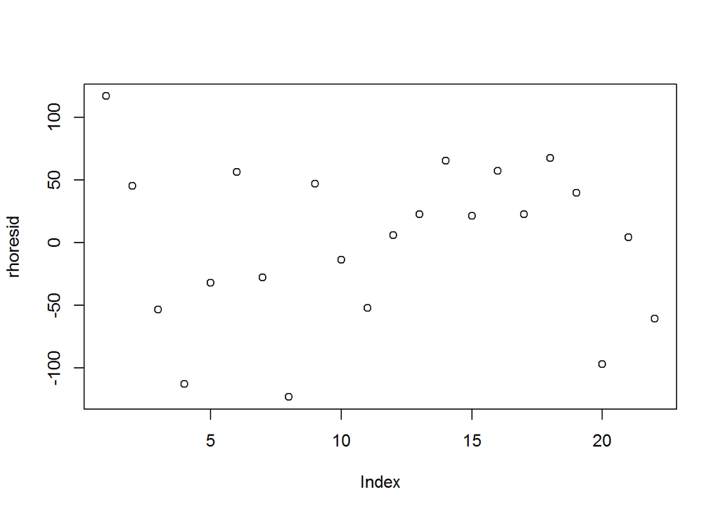

```r
rhoresid <- resid(rhobond)

plot (rhoresid)
```

```r
rbond <- c(NA, rhoresid[1:(length(rhoresid) - 1)])

regb <- lm (rhoresid ~ rbond)

summary (regb)
```

```
##
## Call:
## lm(formula = rhoresid ~ rbond)
##
## Residuals:
##     Min      1Q  Median      3Q     Max
## -112.91  -44.03   19.61   35.70   71.18
##
## Coefficients:
##             Estimate Std. Error t value Pr(>|t|)
## (Intercept)  -5.9965    13.1298  -0.457    0.653
## rbond         0.1489     0.2113   0.704    0.490
##
## Residual standard error: 60.1 on 19 degrees of freedom
##   (1 observation deleted due to missingness)
## Multiple R-squared:  0.02545,    Adjusted R-squared:  -0.02584
## F-statistic: 0.4962 on 1 and 19 DF,  p-value: 0.4897
```

When we check for autocorrelation there appears to no longer be an effect.

### c) Dynamic Model

```r
laggross <- c(NA, bond$GrossRev[1:(length(bond$GrossRev) - 1)])

dynamicreg <- lm (GrossRev ~ laggross + Rating + Budget, data = bond)

summary (dynamicreg)
```

```
##
## Call:
## lm(formula = GrossRev ~ laggross + Rating + Budget, data = bond)
##
## Residuals:
##     Min      1Q  Median      3Q     Max
## -208.27 -110.88   10.51   98.92  265.25
##
## Coefficients:
##               Estimate Std. Error t value Pr(>|t|)
## (Intercept) -1025.6207   299.0101  -3.430 0.002986 **
## laggross        0.5657     0.1598   3.540 0.002341 **
## Rating        190.7528    41.1841   4.632 0.000207 ***
## Budget          0.5178     0.4738   1.093 0.288861
## ---
## Signif. codes:  0 '***' 0.001 '**' 0.01 '*' 0.05 '.' 0.1 ' ' 1
##
## Residual standard error: 137.9 on 18 degrees of freedom
##   (1 observation deleted due to missingness)
## Multiple R-squared:  0.6539, Adjusted R-squared:  0.5962
## F-statistic: 11.34 on 3 and 18 DF,  p-value: 0.0002083
```

```r
longtermbond <- dynamicreg$coefficients[3] / (1- dynamicreg$coefficients[2])

longtermbond
```

```
##   Rating
## 439.2288
```

From this model we can see that a short term effect of a one unit increase in rating will lead to an increase in 190 million dollars in gross revenue.

The long term effect of a one unit increase (longtermbond) is 439.2 million dollars.

### d) Stationarity

```r
deltarev <- bond$GrossRev - laggross

lagdeltarev <- c(NA, deltarev[1:(N-1)])

dickeyrev <- lm (deltarev ~ laggross + order + lagdeltarev, data = bond)

summary (dickeyrev)
```

```
##
## Call:
## lm(formula = deltarev ~ laggross + order + lagdeltarev, data = bond)
##
## Residuals:
##     Min      1Q  Median      3Q     Max
## -307.16 -123.35  -36.54   96.66  482.93
##
## Coefficients:
##              Estimate Std. Error t value Pr(>|t|)
## (Intercept) 309.98724  284.65343   1.089    0.291
## laggross     -0.46867    0.33404  -1.403    0.179
## order        -0.35363    9.05463  -0.039    0.969
## lagdeltarev   0.05768    0.29741   0.194    0.849
##
## Residual standard error: 210.7 on 17 degrees of freedom
##   (2 observations deleted due to missingness)
## Multiple R-squared:  0.1569, Adjusted R-squared:  0.008148
## F-statistic: 1.055 on 3 and 17 DF,  p-value: 0.3941
```

For Gross Revenue we see that the variable is non stationary, which means we should use a differenced model.

```r
lagbudget <- c(NA, bond$Budget[1:(N-1)])

deltabudget <- bond$Budget - lagbudget

lagdeltabudget <- c(NA, deltabudget[1:(N-1)])

dickeybudget <- lm (deltabudget ~ lagbudget + order + lagdeltabudget, data = bond)

summary (dickeybudget)
```

```
##
## Call:
## lm(formula = deltabudget ~ lagbudget + order + lagdeltabudget,
##     data = bond)
##
## Residuals:
##     Min      1Q  Median      3Q     Max
## -60.308 -23.257  -6.795  25.045  84.244
##
## Coefficients:
##                Estimate Std. Error t value Pr(>|t|)
## (Intercept)    -8.25273   19.09084  -0.432   0.6710
## lagbudget      -0.63175    0.32748  -1.929   0.0706 .
## order           5.62689    2.70645   2.079   0.0531 .
## lagdeltabudget -0.07566    0.29595  -0.256   0.8013
## ---
## Signif. codes:  0 '***' 0.001 '**' 0.01 '*' 0.05 '.' 0.1 ' ' 1
##
## Residual standard error: 35.82 on 17 degrees of freedom
##   (2 observations deleted due to missingness)
## Multiple R-squared:  0.3463, Adjusted R-squared:  0.2309
## F-statistic: 3.001 on 3 and 17 DF,  p-value: 0.0595
```

```r
lagrating <- c(NA, bond$Rating[1:(N-1)])

deltarating <- bond$Rating - lagrating

lagdeltarating <- c(NA, deltarating[1:(N-1)])

dickeyrating <- lm (deltarating ~ lagrating + order + lagdeltarating, data = bond)

summary (dickeyrating)
```

```
##
## Call:
## lm(formula = deltarating ~ lagrating + order + lagdeltarating,
##     data = bond)
##
## Residuals:
##     Min      1Q  Median      3Q     Max
## -1.0440 -0.3841 -0.1609  0.3409  1.4265
##
## Coefficients:
##                Estimate Std. Error t value Pr(>|t|)
## (Intercept)     2.36852    2.16975   1.092   0.2902
## lagrating      -0.41114    0.29962  -1.372   0.1878
## order           0.02457    0.02757   0.891   0.3853
## lagdeltarating -0.47270    0.23978  -1.971   0.0652 .
## ---
## Signif. codes:  0 '***' 0.001 '**' 0.01 '*' 0.05 '.' 0.1 ' ' 1
##
## Residual standard error: 0.6772 on 17 degrees of freedom
##   (2 observations deleted due to missingness)
## Multiple R-squared:  0.4976, Adjusted R-squared:  0.409
## F-statistic: 5.613 on 3 and 17 DF,  p-value: 0.007319
```

### e) Differenced Model

```r
diff <- lm (deltarev ~ lagdeltarev + deltabudget + deltarating)

summary (diff)
```

```
##
## Call:
## lm(formula = deltarev ~ lagdeltarev + deltabudget + deltarating)
##
## Residuals:
##      Min       1Q   Median       3Q      Max
## -312.263  -97.617   -5.694  104.583  265.073
##
## Coefficients:
##             Estimate Std. Error t value Pr(>|t|)
## (Intercept)   1.9796    42.7566   0.046    0.964
## lagdeltarev   0.1232     0.2552   0.483    0.635
## deltabudget   2.1827     1.4201   1.537    0.143
## deltarating 201.1315    70.5423   2.851    0.011 *
## ---
## Signif. codes:  0 '***' 0.001 '**' 0.01 '*' 0.05 '.' 0.1 ' ' 1
##
## Residual standard error: 186.1 on 17 degrees of freedom
##   (2 observations deleted due to missingness)
## Multiple R-squared:  0.3428, Adjusted R-squared:  0.2268
## F-statistic: 2.955 on 3 and 17 DF,  p-value: 0.06203
```

With the difference model we find the rating of the film has a strong relationship with the gross revenue of the film. A one unit increase in the film rating will mean a 201.13 million dollar increase in gross revenue.

### f) Actor worth

```r
diffactor <- lm (deltarev ~ lagdeltarev + deltabudget + deltarating + Actor, data = bond)

summary (diffactor)
```

```
##
## Call:
## lm(formula = deltarev ~ lagdeltarev + deltabudget + deltarating +
##     Actor, data = bond)
##
## Residuals:
##     Min      1Q  Median      3Q     Max
## -332.18  -64.51   12.91   80.69  259.77
##
## Coefficients:
##               Estimate Std. Error t value Pr(>|t|)
## (Intercept)    28.4163   103.3474   0.275   0.7880
## lagdeltarev    -0.0983     0.2963  -0.332   0.7458
## deltabudget     1.8975     1.6698   1.136   0.2780
## deltarating   179.9989    91.2623   1.972   0.0721 .
## ActorConnery  103.7267   141.3999   0.734   0.4773
## ActorCraig     34.8142   151.8894   0.229   0.8226
## ActorDalton  -134.3512   165.0488  -0.814   0.4315
## ActorLazenby -309.1929   236.1223  -1.309   0.2149
## ActorMoore    -56.8715   128.1158  -0.444   0.6650
## ---
## Signif. codes:  0 '***' 0.001 '**' 0.01 '*' 0.05 '.' 0.1 ' ' 1
##
## Residual standard error: 188.6 on 12 degrees of freedom
##   (2 observations deleted due to missingness)
## Multiple R-squared:  0.5233, Adjusted R-squared:  0.2054
## F-statistic: 1.646 on 8 and 12 DF,  p-value: 0.2103
```

Actor does not appear to have a significant effect on the gross revenue of a Bond film. Therefore, we cannot reject the null hypothesis.

### Question 15.1

```r
olympics <- import ("olympics_HW.dta")
```

### a) One way fixed effects model

```r
oneway <- tidy(lm (medals ~ population + GDP + host + temp + elevation + country, data = olympics))

head(oneway)
```

```
##          term      estimate    std.error     statistic      p.value
## 1 (Intercept) -5.274986e-01 12.321497908 -0.0428112390 9.658622e-01
## 2  population  1.282955e-02  0.003562288  3.6014925577 3.349234e-04
## 3         GDP  8.165972e-01  0.097428385  8.3815117778 2.179863e-16
## 4        host  5.764501e+00  0.995971671  5.7878166770 1.005715e-08
## 5        temp -3.118156e-05  0.051439845 -0.0006061753 9.995165e-01
## 6   elevation  1.294068e-04  0.004664436  0.0277433021 9.778735e-01
```

Using this one way fixed effects model we estimate that Population, GDP and Host country all play a significant positive role in medal count (at the 0.05 level). Temperature and elevation do not play a significant role and the coefficients show that there is not a substantive effect.

### b) Two way fixed effects

```r
twoway <- plm (medals ~ population + GDP + host, data = olympics, index = c("country", "year"),
               model = "within", effect = "twoways")

tidy (twoway)
```

```
##         term    estimate   std.error statistic      p.value
## 1 population 0.008549258 0.003754531  2.277051 2.303446e-02
## 2        GDP 0.593507203 0.123049435  4.823323 1.676849e-06
## 3       host 5.712385319 0.988933701  5.776308 1.075839e-08
```

In the two way fixed effects model we find that the results are significant at the 0.05 level. Population and GDP are less significant compared to the results in part a. The coefficients also show a less substantive effect. The values for host stay relatively similar. We would assume that since we are including time as a fixed effect it would remove the effects of population and GDP (which may grow or fluctuate over time)

### c) Autocorrelation

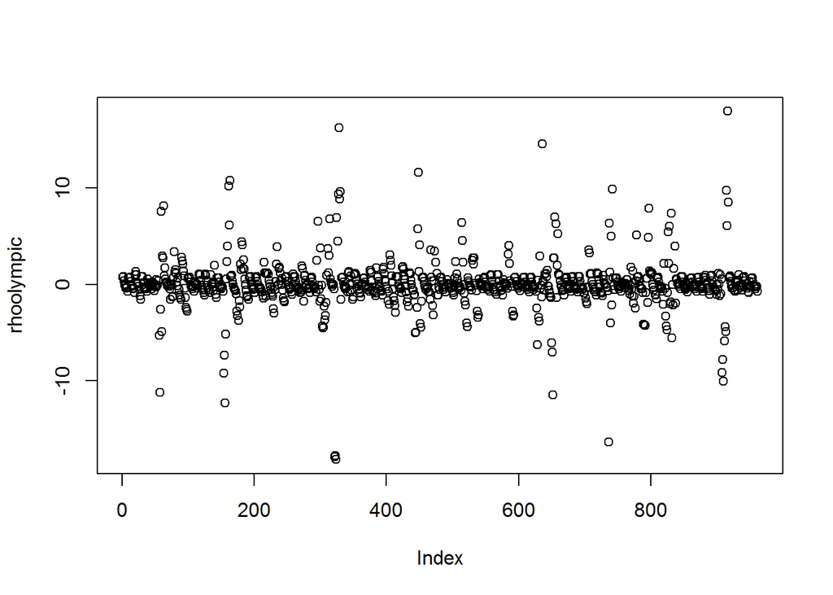

```r
rhoolympic <- resid(twoway)

plot (rhoolympic)
```

```r
rolympic <- c(NA, rhoolympic[1:(length(rhoolympic) - 1)])

rego <- lm (rhoolympic ~ rolympic)

summary (rego)
```

```
##
## Call:
## lm(formula = rhoolympic ~ rolympic)
##
## Residuals:
##      Min       1Q   Median       3Q      Max
## -17.6820  -0.4840  -0.1695   0.4370  15.2085
##
## Coefficients:
##              Estimate Std. Error t value Pr(>|t|)
## (Intercept) -0.001091   0.073856  -0.015    0.988
## rolympic     0.446442   0.028910  15.442   <2e-16 ***
## ---
## Signif. codes:  0 '***' 0.001 '**' 0.01 '*' 0.05 '.' 0.1 ' ' 1
##
## Residual standard error: 2.288 on 958 degrees of freedom
##   (1 observation deleted due to missingness)
## Multiple R-squared:  0.1993, Adjusted R-squared:  0.1985
## F-statistic: 238.5 on 1 and 958 DF,  p-value: < 2.2e-16
```

We find a highly significant value which implies autocorrelation. We should therefore correct for autocorrelation by including lagged variables.

### d) Correct for autocorrelation

```r
orho <- summary (rego)$coefficients[2]

N <- length(olympics$medals)

lagmedal <- c(NA, olympics$medals[1:(N-1)])

lagyear <- c(NA, olympics$year[1:(N-1)])

medalrho <- mean(olympics$medals) - orho * lagmedal

yearrho <- olympics$year - orho * lagyear

olympics$yearrho <- yearrho

rhomedal <- plm (medalrho ~ population + GDP + host, data = olympics,
                 index = c("country", "yearrho"),
                 effect = "twoway",
                 model = "within")
```

```
## at least one couple (id-time) has NA in at least one index dimension in resulting pdata.frame
##  to find out which, use e.g. table(index(your_pdataframe), useNA = "ifany")
```

```r
summary (rhomedal)
```

```
## Twoways effects Within Model
##
## Call:
## plm(formula = medalrho ~ population + GDP + host, data = olympics,
##     effect = "twoway", model = "within", index = c("country",
##         "yearrho"))
##
## Unbalanced Panel: n=111, T=1-10, N=960
##
## Residuals :
##    Min. 1st Qu.  Median 3rd Qu.    Max.
## -10.200  -0.379   0.093   0.302   7.710
##
## Coefficients :
##               Estimate  Std. Error t-value Pr(>|t|)
## population  0.00039391  0.00212523  0.1853 0.853000
## GDP        -0.22693808  0.06986494 -3.2482 0.001208 **
## host       -0.68400970  0.56849692 -1.2032 0.229244
## ---
## Signif. codes:  0 '***' 0.001 '**' 0.01 '*' 0.05 '.' 0.1 ' ' 1
##
## Total Sum of Squares:    2028
## Residual Sum of Squares: 1997.9
## R-Squared:      0.014847
## Adj. R-Squared: -0.13145
## F-statistic: 4.19482 on 3 and 835 DF, p-value: 0.005858
```

Now we see that GDP has a significant effect on medal count and this effect is negative. For every unit increase in GDP there is a decrease of 0.22 medals. The first model appears to be better because this model does not appear to pass face validity. It is strange that GDP would negatively effect a country’s medal count. The reality of the Olympics demonstrates that countries with high GDPs have more medals and they invest in athletes.

### e)

```r
lagmedal2 <- plm (medals ~ lagmedal + GDP + host + population, data = olympics,
                 index = c("country", "year"),
                 effect = "twoway",
                 model = "within")
summary (lagmedal2)
```

```
## Twoways effects Within Model
##
## Call:
## plm(formula = medals ~ lagmedal + GDP + host + population, data = olympics,
##     effect = "twoway", model = "within", index = c("country",
##         "year"))
##
## Unbalanced Panel: n=111, T=1-10, N=961
##
## Residuals :
##     Min.  1st Qu.   Median  3rd Qu.     Max.
## -13.1000  -0.4650  -0.0986   0.5080  18.4000
##
## Coefficients :
##             Estimate Std. Error t-value  Pr(>|t|)
## lagmedal   0.3146559  0.0241948 13.0051 < 2.2e-16 ***
## GDP        0.4189832  0.1130975  3.7046 0.0002256 ***
## host       5.2515080  0.9032252  5.8142 8.664e-09 ***
## population 0.0085312  0.0034265  2.4898 0.0129751 *
## ---
## Signif. codes:  0 '***' 0.001 '**' 0.01 '*' 0.05 '.' 0.1 ' ' 1
##
## Total Sum of Squares:    6701.3
## Residual Sum of Squares: 5212.5
## R-Squared:      0.22216
## Adj. R-Squared: 0.10786
## F-statistic: 59.7654 on 4 and 837 DF, p-value: < 2.22e-16
```

From this model we find a similar result to the model in part b. The only difference is that lagmedal plays a significant role in the result. Countries that win the olympic medals in one olympics are more likely to win again in the next.

### f) Autocorrelation testing

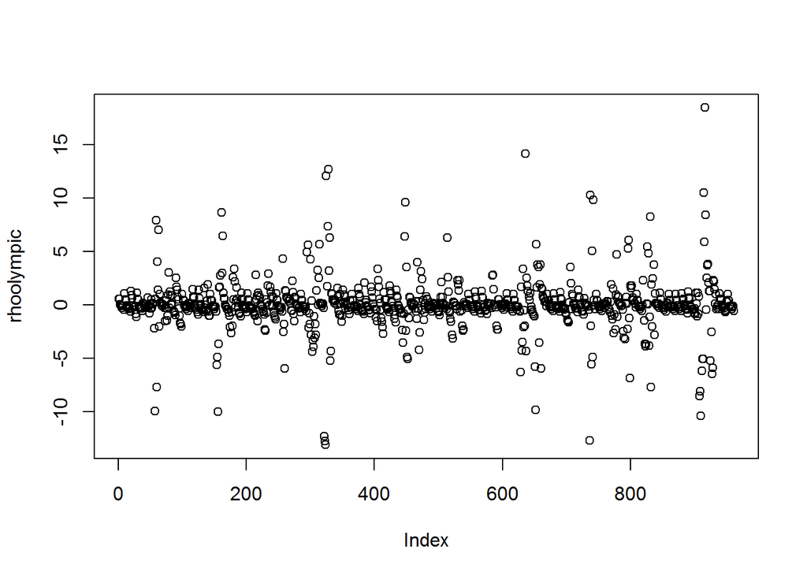

```r
rhoolympic <- resid(lagmedal2)

plot (rhoolympic)
```

```r
rolympic <- c(NA, rhoolympic[1:(length(rhoolympic) - 1)])

rego <- lm (rhoolympic ~ rolympic)

summary (rego)
```

```
##
## Call:
## lm(formula = rhoolympic ~ rolympic)
##
## Residuals:
##      Min       1Q   Median       3Q      Max
## -12.5889  -0.4237  -0.1325   0.3863  17.2975
##
## Coefficients:
##              Estimate Std. Error t value Pr(>|t|)
## (Intercept) -0.000696   0.073877  -0.009    0.992
## rolympic     0.192304   0.031705   6.065 1.89e-09 ***
## ---
## Signif. codes:  0 '***' 0.001 '**' 0.01 '*' 0.05 '.' 0.1 ' ' 1
##
## Residual standard error: 2.289 on 958 degrees of freedom
##   (1 observation deleted due to missingness)
## Multiple R-squared:  0.03698,    Adjusted R-squared:  0.03598
## F-statistic: 36.79 on 1 and 958 DF,  p-value: 1.893e-09
```

There is evidence of a highly significant autocorrelation, this means there is a biased result. This implies we should include rho- transformed values in the regression to control for the autocorrelation.

### g)

```r
rholag <- plm (medalrho ~ lagmedal + population + GDP + host, data = olympics,
                 index = c("country", "yearrho"),
                 effect = "twoway",
                 model = "within")
```

```
## at least one couple (id-time) has NA in at least one index dimension in resulting pdata.frame
##  to find out which, use e.g. table(index(your_pdataframe), useNA = "ifany")
```

```r
summary (rholag)
```

```
## Twoways effects Within Model
##
## Call:
## plm(formula = medalrho ~ lagmedal + population + GDP + host,
##     data = olympics, effect = "twoway", model = "within", index = c("country",
##         "yearrho"))
##
## Unbalanced Panel: n=111, T=1-10, N=960
##
## Residuals :
##      Min.   1st Qu.    Median   3rd Qu.      Max.
## -1.05e-14 -5.18e-16 -1.63e-16  1.59e-16  9.00e-14
##
## Coefficients :
##               Estimate  Std. Error     t-value Pr(>|t|)
## lagmedal   -4.4644e-01  3.2957e-17 -1.3546e+16   <2e-16 ***
## population  2.1716e-18  4.5336e-18  4.7900e-01   0.6321
## GDP         9.9668e-17  1.4997e-16  6.6460e-01   0.5065
## host       -7.6683e-17  1.2138e-15 -6.3200e-02   0.9496
## ---
## Signif. codes:  0 '***' 0.001 '**' 0.01 '*' 0.05 '.' 0.1 ' ' 1
##
## Total Sum of Squares:    2028
## Residual Sum of Squares: 9.0805e-27
## R-Squared:      1
## Adj. R-Squared: 1
## F-statistic: 4.65651e+31 on 4 and 834 DF, p-value: < 2.22e-16
```

In this model there is no longer a statistically significant effect from population, GDP or host country on medal count. There is only a significant coefficient on lagmedals, which is negative. Which is a strange result since medals won previously would reduce the future medals being won. The model is questionable.

### h)

In section 15.2 they state that fixed effects model bias is not a problem when there are 20 or more time periods. However, the data in this set is from 1980 to 2014 and therefore we only have 10 periods. This is not enough to reduce the bias from the fixed effects model. The results are suspect.

### i) Lagged dependent variable or autocorrelation?

Athletes often compete in multiple olympic games and sometimes win medals in several olympics games in a row (Michael Phelps and Usain Bolt as some examples) There is probably a dynamic component to the model. 13.4 states that if a model is dynamic then we should probably use lagged dependent variables. Some bias could be introduced if autocorrelation happens, but if we do not include the term we could end up with omitted variable bias. Therefore, a dynamic model would be better to use in this case.

### j) Robustness

Robustness refers to a result that does not change if we change the model (section 2.2). These models are not robust as the explanatory variables change when we change the model. The variables sometimes are significant, and sometimes they are not. Furthermore, the substantive effect also changes with some results showing a positive effect and some not. The results are highly impacted by the model type.